# Data Scraping & Wrangling

- Kathirmani Sukumar
  - Data Scientist & co-founder @Quelit
- Note: This presentation is created using jupyter notebook. Images under many slides will be visible only if connected to internet.

### Types of data sources

- **Directly downloadable**: Historical data that can be downloaded directly as CSV, JSON, Excel, DB dumps
  - [UCI Machine Learning repository](https://archive.ics.uci.edu/ml/index.php)
  - [Kaggle data sets](https://www.kaggle.com/datasets)
  - data.gov.in
  - [IBM datasets](https://www.ibm.com/communities/analytics/watson-analytics-tag/datasets/)
- **Online API** : Latest data can be pull from APIs using any programming languages like R, Python etc
  - [Twitter - Tweets](https://developer.twitter.com/en/docs/basics/getting-started)
  - [Zomato - Restaturants](https://developers.zomato.com/api)
  - [Github - Repositories](https://developer.github.com/v3/)
- **Webpages**: Data cannot be downloaded or pulled like above two. Users can browse and collect information. Intent is not to provide data directly. Intent is to let users spend time in their websites
  - [Medium articles](https://medium.com)
  - [Jobs postings in Naukri portal](https://www.naukri.com/data-science-jobs)
  - [Book reviews in Goodreads](https://www.goodreads.com/choiceawards/best-books-2017)

# Online API

**Defintion**: An Application Programming Interface (API) is code that allows two software programs to communicate with each other to exchange information (data).

**Example**: Extracting live tweets from Twitter API from Python or R

**Types of Requests**

- `GET`
  - Mainly used to pull data from API
  - Limited data only can be send to the API. These are typically query parameters.
  - For example, query can contain `per_page=100` as additional data to the API to specifiy that we need 100 objects per page or request
  - Not secured
- `POST`
  - Mainly used to send data to API
  - For example sharing reviews in a form, sending passwords securedly
  - No limit for the data size. Depends only on the network bandwidth

### JSON

- **Definition** Javascript Object Notation is an open standard file format that is used to transmit data objects consisting of key-value pairs.
- Advantages
  - Easy for humans to read and write
  - Easy for machines to parse and generate
  - Though derived from Javscript, JSON is a language independent data format

### JSON Structure

```
- The following JSON data starts with a square bracket to represents that the data contains array of objects (each element is called as objects in JSON data)
- Each object contains four attributes of a person.
- Each attribute contains a `key` and a `value` separated by `:`. For example in the first attribute of the first object is `name` who value is `mani`.
```

```
[
    {
        "name":"mani",
        "class":"A",
        "batch":4,
        "role":"student"
    },
    {
        "name":"kathir",
        "class":"A",
        "batch":4,
        "role":"instructor"
    }
]
```

### Access JSON objects in Python

#### Read JSON data directly from a URL

Use `requests` module to read any URL. Since the data is in the JSON data, use `.json()` to directly convert the output to python list. Otherwise JSON data will be read as a string in python

```python
import requests
url = "https://raw.githubusercontent.com/skathirmani/datasets/master/json/d3.json"
data = requests.get(url).json()
type(data)
```

```
list
```

```python
data
```

```
[{'name': 'mani', 'class': 'A', 'batch': 4, 'role': 'student'},
 {'name': 'kathir', 'class': 'A', 'batch': 4, 'role': 'instructor'}]
```

### Wrangling with JSON data

#### Access elements by their position

```python
data[0]
```

```
{'name': 'mani', 'class': 'A', 'batch': 4, 'role': 'student'}
```

#### Access attributes by their `name/key`

```python
data[0]['name']
```

```
'mani'
```

### Convert JSON data in to Pandas Data Frame

- Create empty data frame with necessary columns
- Loop through each object in the data
  - Access necessary attributes
  - Put them together in a single dictionary
  - Append the dictionary as row in to data frame

```python
import pandas as pd
df_student = pd.DataFrame(columns=['name', 'class', 'role'])
for student in data:
    curr_row = {'name': student['name'],
                'class': student['class'],
                'role': student['role']}
    df_student = df_student.append(curr_row, ignore_index=True)

df_student
```

|  | name | class | role |
| --- | --- | --- | --- |
| 0 | mani | A | student |
| 1 | kathir | A | instructor |

# Scraping repositories from `Github` API

- `Github` is like `Facebook` for developers
- Developers can open source their project's code files
- Likewise they can take (fork) or refer to other developer's work
- Every project is a repository
- Profiles can be either for a single user like you and me
  - This is my [github repository](https://github.com/skathirmani/) :)
- Profiles can be of type organizations
  - This is list of projects from google as an organizaiton
- Read the [github api](https://developer.github.com/v3/) documentation
  - Why we need to read API documentation?: To know the different types of URL to pull data

#### Read the Repositories data from Google

```python
url_google = "https://api.github.com/orgs/google/repos"
page = requests.get(url_google).json()
```

By default data about 30 repositories can be extracted

```python
len(page)
```

```
30
```

#### Access individual attributes of the repositories

```python
print(page[0]['id'])
print(page[0]['name'])
print(page[0]['language'])
print(page[0]['size'])
print(page[0]['watchers'])
print(page[0]['stargazers_count'])
print(page[0]['open_issues'])
print(page[0]['subscribers_url'])
```

```
196334
upb
C
5364
912
912
23
https://api.github.com/repos/google/upb/subscribers
```

### Append objects to Pandas Data Frame

- Create empty data frame with necessary columns
- Loop through each object in the data
  - Append the dictionary as row in to data frame
  - **Note**: While appending use `ignore_index=True` to let pandas know that it should not look for any index in the new data, instead increment row index by 1

```python
cols = ['organization', 'id', 'name', 'language',
       'size', 'watchers', 'stargazers_count',
       'open_issues', 'subscribers_url']
repos = pd.DataFrame(columns=cols)
for repo in page:
    curr_row = {
        'organization': 'google',
        'id': repo['id'],
        'name': repo['name'],
        'language': repo['language'],
        'size': repo['size'],
        'watchers': repo['watchers'],
        'subscribers_url': repo['subscribers_url'],
        'stargazers_count': repo['stargazers_count'],
        'open_issues': repo['open_issues'],
    }
    repos = repos.append(curr_row, ignore_index=True)
repos.head(2)
```

|  | organization | id | name | language | size | watchers | stargazers_count | open_issues | subscribers_url |
| --- | --- | --- | --- | --- | --- | --- | --- | --- | --- |
| 0 | google | 196334 | upb | C | 5364 | 912 | 912 | 23 | https://api.github.com/repos/google/upb/subscr... |
| 1 | google | 1936771 | truth | Java | 26119 | 1514 | 1514 | 51 | https://api.github.com/repos/google/truth/subs... |

### Get repositories subscribers

- The earlier results only gives high level information about each repositories
- Use `subscribers_url` column to loop through each repository one by one individually to get subscribers list

```python
subscribers = pd.DataFrame(columns=['repo_name', 'follower_name',
                                    'follower_id'])
for i, repo in repos.head(20).iterrows():
    curr_repo = repo['name']
    sub_url = repo['subscribers_url']
    page = requests.get(sub_url).json()
    for follower in page:
        # print(curr_repo, follower['login'], follower['id'])
        curr_row = {'repo_name': curr_repo,
                    'follower_name': follower['login'],
                    'follower_id': follower['id']}
        subscribers = subscribers.append(curr_row, ignore_index=True)
subscribers.head(2)
```

|  | repo_name | follower_name | follower_id |
| --- | --- | --- | --- |
| 0 | upb | haberman | 1270 |
| 1 | upb | eric-zhou | 1322233 |

# Twitter Web Scraping

- Get a twitter account
- Apply for a developer account and create an application in https://apps.twitter.com
- Get the following keys under `Keys and Access Tokens`
  - `Consumer Key (API Key)`
  - `Consumer Secret (API Secret)`
  - `Access Token`
  - `Access Token Secret`

### Scrape tweets through Tweepy Package

```python
import pandas as pd
import tweepy

tweepy.__version__
```

```
'3.6.0'
```

### Authenticate yourself from python to twitter API

- Make sure that you copy paste the keys correctly.
- No additional space should be added
- Do be under any proxy. Check if your internet works :)

```python
consumer_key = 'L52hGabe0YLDpcjz9c9U0Idx3' # Paste your keys here
consumer_secret = 'QAKs4gzRFT71UQkEWfEq3DTFJbb92UXRGpoJXO6DjDjeBa5fuW'
access_token = '150321726-05rge3dWrV8c7FUpLNP3ksREhRYt9x1Z0R6zgosA'
access_token_secret = 'kNnEI1K9pud0o8BVeWdomVMHBjAUVQXedNgCwU2Spykck'
auth = tweepy.OAuthHandler(consumer_key, consumer_secret)
auth.set_access_token(access_token, access_token_secret)

# Access Twitter API
api = tweepy.API(auth, wait_on_rate_limit=True)
api
```

```
<tweepy.api.API at 0x1103c0cf8>
```

### Get tweets from User's timeline

```python
tweets_user = api.user_timeline('narendramodi', count=100)
len(tweets_user)
```

```
100
```

The output is of type tweepy object

```python
type(tweets_user)
```

```
tweepy.models.ResultSet
```

### Create a data frame

- Loop through each object in the result and append the data to the data frame
- Store the data frame in a `CSV` file. Use `index=False` to make sure that row labels/index are not added to the CSV file

```python
tweets = pd.DataFrame(columns=['id', 'created_at', 'likes',
                              'retweets', 'text', 'source'])

for tweet in tweets_user:
    curr_tweet = {'id': tweet.id,
                 'created_at': tweet.created_at,
                 'likes': tweet.favorite_count,
                 'retweets': tweet.retweet_count,
                 'text': tweet.text,
                 'source': tweet.source}
    tweets = tweets.append(curr_tweet, ignore_index=True)
tweets.to_csv('modi_tweets.csv', index=False)
tweets.head(2)
```

|  | id | created_at | likes | retweets | text | source |
| --- | --- | --- | --- | --- | --- | --- |
| 0 | 1050753471794671617 | 2018-10-12 14:22:04 | 345 | 106 | The philosophy of 'Sabka Saath, Sabka Vikas' e... | Media Studio |
| 1 | 1050752924219977729 | 2018-10-12 14:19:53 | 552 | 136 | For us, human rights &amp; their protection ar... | Media Studio |

### Data Wrangling

```python
tweets['created_at'].min(), tweets['created_at'].max()
```

```
(Timestamp('2018-10-02 12:08:10'), Timestamp('2018-10-12 14:22:04'))
```

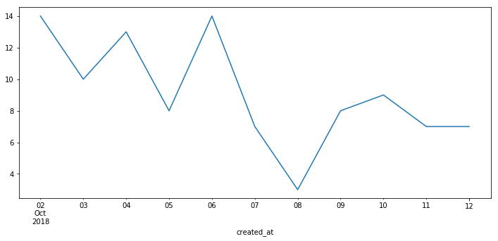

```python
# To plot charts below the cell itself
%matplotlib inline

tweets.index = tweets['created_at']
tweets.resample('1D')['id'].count().plot.line(figsize=(12, 5))
```

### Create wordcloud using online generator

- Open the tweets data using excel
- Copy the `text` column completely
- Go to https://www.wordclouds.com
- Choose `File -> Paste/Type text`
- Paste the text as such
- Click `Apply` to generate the wordcloud

[figure not shown]

### Search for tweets based on keywords or hashtags

```python
tweets_datascience = api.search('#datascience', count=50)
len(tweets_datascience)
```

```
47
```

```python
tweets_df = pd.DataFrame(columns=['text', 'retweets', 'likes', 'user', 'screen_name'])
for tweet in list(tweets_datascience):
    tweet_series = pd.Series({'text': tweet.text, 'date': tweet.created_at,
                          'retweets': tweet.retweet_count,
                          'likes': tweet.favorite_count,
                          'user': tweet.user.name,
                          'screen_name': tweet.user.screen_name})
    tweets_df = tweets_df.append(tweet_series, ignore_index=True)
tweets_df.head(1)
```

|  | text | retweets | likes | user | screen_name | date |
| --- | --- | --- | --- | --- | --- | --- |
| 0 | RT @adityasridhar18: Came across this today. N... | 1 | 0 | Alison B Lowndes ✿ | AlisonBLowndes | 2018-10-12 14:34:05 |

# Web Scraping

- Scraping jobs from www.naukri.com

**Definition**: Web Scraping is a technique employed to extract large amounts of data from websites whereby the data is extracted and saved to a local file in your computer or to a database in table format

- Data displayed by most websites can only be viewed usig web browser
- They do not offer the functionality to save a copy of this data for personal use
- The only option is to manually copy and paste the data - a very tedius job which can take many hourse
- `Web scraping` is the technique of automating this process ###### Source: www.webharvy.com

### Web scraping process

- Retrieving HTML data from a domain name
- Parsing that data for target information
- Storing the target information
- Optionally, moving to another page to repeat the process

### Reading a web page in Python

While reading a web page using `requests`, we want to read the html content of the page. Hence we use `.text` method. Unlike in online APIs, where use `.json()` to read JSON data from URL. The output will be of type `str`. This will be a very long string. The entire website HTML tags are read as single string

```python
import bs4
naukri_url = 'https://www.naukri.com/data-scientist-jobs'
page = requests.get(naukri_url).text
print(type(page))
print(len(page))
print(page[:1000])
```

```
<class 'str'>
168744
 <!DOCTYPE HTML> <html class="srpPage">  <head>   <link rel="canonical" href="https://www.naukri.com/data-scientist-jobs"/>    <meta charset="UTF-8" /> <meta http-equiv="X-UA-Compatible" content="IE=Edge" /> <link rel="manifest" href="https://www.naukri.com/notifymanifest.json"/>    <title> Data Sci…
```

### Use BeautifulSoup to parse the string

- BeautifulSoup helps format and organize the messy web string and presenting us with easily-traversible Python objects
- The first step with BeautifulSoup is to parse the downloaded HTML in to a soup document

```python
bs_obj = bs4.BeautifulSoup(page, 'html.parser')
```

#### Get necessary HTML tags

- `<html>` tag - Parent for all tags
  - `<head>` tag contains styles, links to external style sheets. Not visible directly in browser
    - `<title>` tag contains the title of the web page. This text inside this tag will be displayed in the browser tab
  - `<body>` tag contains all the content of the webpage which is visible to us
    - `<p>` tag used for placing text in to different paragraphs
    - `<img>` tag used to place images
    - `<a>` (anchor) tag used to redirect or open to other web pages
    - `<div>` tag used to wrap other tags together
    - `<li>` tag used to created bulleted list

```python
print(bs_obj.title)
print(bs_obj.title.text)
```

```
<title> Data Scientist Jobs - Naukri.com </title>
 Data Scientist Jobs - Naukri.com
```

### Inspect Element to access necessary tag

- Right click anywhere in your Chrome browser and choose `Inspect Element` to access the individual tags in the HTML page

[figure not shown]

- Choose the `arrow` icon under inspect element panel
- Point the inspect arrow to the extact position of the paragraph or image or title that you want to scrape
- Look for tag name and see if it contains any `class` or `id`.
- Classes are used for selecting more than one tag at a time. Many tags can have same class. Just like how students can have same class name
- Ids are ideally unique for a single tag. Two tags ideally should not have same ID. Just like how students have their unique IDs
- Example. Let's get the `naukri` logo link
- An `<img>` tag is used inside a `<a>` tag with a class `nLogo`

```python
bs_obj.find('a', {'class': 'nLogo'})
```

```
<a class="nLogo fl" href="https://www.naukri.com"><img alt="Naukri.com, India’s No.1 Job Site" src="https://static.naukimg.com/s/4/100/i/naukri_Logo.png"/></a>
```

- Find the children after identifying the parent `<a>` tag
- Get the attribute of the image tag `src` which contains the link to the logo

```python
bs_obj.find('a', {'class': 'nLogo'}).find('img').get('src')
```

[output not shown]

```python
bs_obj.find('a', {'class': 'nLogo'}).find('img')
```

[output not shown]

# Scrape jobs

### Identifying the parent tags

- We would like to scrape the jobs listed in the URL
- Each job contains almost same structure. The following attributes are there most of the jobs
  - Title of the post
  - Company name
  - Salary details
  - Job description
  - ....
- Whenever we see such repeating patterns, these individual items should be having the same structure (HTML tags)
  - Jobs in this example
  - Products in any e-commerce websites (Myntra, Amazon, Flipkart)
  - Books in goodreads website
- Identify the parent tag for each individual items. We can see that all the jobs are wrapped in `div` tag with `class=row` and `type=tuple`

[figure not shown]

```python
parents_layouts = bs_obj.findAll('div', {'class': 'row', 'type': 'tuple'})
len(parents_layouts)
```

```
50
```

- Understand the structure of one parent layout
- Identify what information you are going to scrape
- For each information identify the corresponding tag name and any class or other types of attributes to select
- Example show below

[figure not shown]

### Extract information in Python using relavant tags

```python
print(parents_layouts[4].find('li', {'class': 'desig'}).get('title'))
print(parents_layouts[4].find('span', {'class': 'loc'}).text)
print(parents_layouts[4].find('span', {'class': 'desc'}).text)
```

```
Lead Data Scientist (deep Learning & Machine Learning)
Bengaluru
Expert level knowledge in machine learning algorithms (XGBoost, Linear and Logistic regression , SVM, ...
```

### Loop through each parent and append rows to data frame

- The function `cn` is used to handle any error while extracting information
- Becuase few jobs might not have all the required information

```python
jobs = pd.DataFrame(columns=['id', 'title', 'location', 'experience',
                            'skills', 'company', 'salary', 'description',
                            'posted_date', 'type', 'url'])
def cn(tag):
    try:
        return (tag.text)
    except AttributeError:
        return (None)

for p in parents_layouts:
    row = {
        'id': p.get('id'),
        'description': cn(p.find('span', {'class': 'desc'})),
        'location': cn(p.find('span', {'class': 'loc'})),
        'experience': cn(p.find('span', {'class': 'exp'})),
        'company': cn(p.find('span', {'class': 'org'})),
        'skills': cn(p.find('span', {'class': 'skill'})),
        'salary': cn(p.find('span', {'class': 'salary'})),
        'posted_date': cn(p.find('span', {'class': 'date'})),
        'title': p.find('li', {'class': 'desig'}).get('title'),
        'type': p.find('span', {'class': 'jobType'}).get('class')[-1],
    }
    jobs = jobs.append(row, ignore_index=True)
jobs.head(2)
```

|  | id | title | location | experience | skills | company | salary | description | posted_date | type | url |
| --- | --- | --- | --- | --- | --- | --- | --- | --- | --- | --- | --- |
| 0 | 131018004005 | Good Opportuity for Data Scientist | Chennai | 5-8 yrs | R, PYTHON, Machine Learning | BAHWAN CYBERTEK PRIVATE LIMITED | Not disclosed | With rich experience delivering digital transf... | 1 day ago | hotjob | NaN |
| 1 | 131018003005 | Immediate Hiring for Data Scientist with Finte... | Bengaluru | 4-9 yrs | machine learning, statistical analysis, risk m... | V3 Staffing Solutions India Pvt. Ltd | Not disclosed | Skills : Credit Risk, Predictive Modelling, Cu... | 1 day ago | hotjob | NaN |

# Regular Expression

**Definition**: A regular expression, regex or regexp is a sequence of characters that define a search pattern

- Reference: https://www.rexegg.com/regex-quickstart.html

### Remove all alphabets (lower + uppper case)

```python
jobs['salary'].str.replace('[a-zA-Z]', '').head()
```

```
0
1
2        10,00,000 - 20,00,000 ..
3        20,00,000 - 35,00,000 ..
4        15,00,000 - 20,00,000 ..
Name: salary, dtype: object
```

### Retain only numbers and hyphens

```python
jobs['salary'].str.replace('[^0-9-]', '').head()
```

```
0
1
2    1000000-2000000
3    2000000-3500000
4    1500000-2000000
Name: salary, dtype: object
```

# Selenium

- Many website do not load contents of the web page in a single requests (very loosely we can say that these websites are static websites, like wikipedia). Instead first they serve the base template of the website. Through javascript ajax requests they load the additional information one by one. Otherwise it will take long time for the websites like Flipkart, Amazon to load.
- Beautifulsoup cannot read the full content of the webpage in to python. Hence we can move to other scrapping libraries like Selenium.
- Selenium opens a live connection between python and the webpage we are trying to read. Hence full content of the website is easy to scrape for many website. Said that, it does not mean that we can scrape all the website. There are many websites which are difficult to scrape

### Scraping products details from Myntra

Let us try using beautifulsoup

```python
import selenium
myntra_url = "https://www.myntra.com/under-599-store"
```

#### Through BeautifulSoup

```python
page = requests.get(myntra_url).text
bs_obj = bs4.BeautifulSoup(page, 'html.parser')
bs_obj.findAll('div',{'class': 'product-brand'})
```

```
[]
```

Though the above `div` tag with class `product-brand` exists in the webpage, through beautiful soup we are not able to scrape the information. For such not static websites, we can use selenium instead of beautifulsoup

#### Through Selenium

By running below code, new chrome window will open and automatically redirects to myntra website

```python
from selenium import webdriver
browser = webdriver.Chrome('/Users/skathirmani/Softwares/chromedriver')
browser.get(myntra_url)
```

### CSS Selectors

- In CSS, selectors are patterns used to select the element(s) you want to style.
- Reference: https://www.w3schools.com/cssref/css_selectors.asp
- Assume the tag `<div class="abc" id="123" type="tuple">Jobs</div>`
- Selecting elements by their class name
  - Syntax: `<tag-name>.<class-name>`
  - Example: `span.product-discountedPrice`
- Selecting elements by their id
  - Syntax: `<tag-name>#<id>`
  - Example: `span#124`
- Selecting elements by their attribute. Assume the following tag
  - Syntax: `<tag-name>[<attribute-key>=<attribute-value>]`
  - Example: `span[type="tuple"]`

```python
products = browser.find_elements_by_css_selector('span.product-discountedPrice')
```

```python
for product in products[:2]:
    print (product.get_attribute('innerHTML'))
```

```
<!-- react-text: 460 -->Rs. <!-- /react-text --><!-- react-text: 461 -->483<!-- /react-text -->
<!-- react-text: 490 -->Rs. <!-- /react-text --><!-- react-text: 491 -->550<!-- /react-text -->
```

### Control website from Python

- You can click elements
- You can fill forms
- You can redirect to another URL

#### Click elements from Python

```python
browser = webdriver.Chrome('/Users/skathirmani/Softwares/chromedriver')
browser.get('https://www.naukri.com')
browser.find_element_by_css_selector('span.searchJob').click()
```

#### Enter value in a search box

```python
srch_bar = browser.find_element_by_css_selector('input.sugInp')
srch_bar.send_keys('data visualization')
```

#### Get current URL

```python
browser.current_url
```

```
'https://www.naukri.com/'
```